# South African Anchovy Operating Model Specification

A plausible hypothetical state of nature for investigating the tailored Climate Test.

Tom Carruthers (tom@bluematterscience.com)

2026-11-17

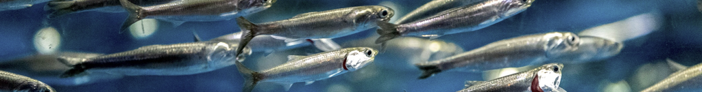

[figure not shown]

# 1 Foreword

This operating model is for conducting exploratory, didactic analyses and is not intended to inform management decision making at this stage. All data used in the construction of these operating models are publicly available from sources that are cited.

# 2 Introduction

This operating model aims to closely mimic the recent benchmark stock assessment of South African anchovy (*Engraulis encrasicolus*) by de Moor (2024) for the purposes of testing the robustness of management procedures to projected climate changes originating from an Atlantis Ecosystem Model ([Ortega-Cisneros et al. 2018](https://onlinelibrary.wiley.com/doi/10.1111/fog.12268)). The baseline assessment model (ABH) assumes time-invariant natural mortality (1.2 per year for juveniles and adults), a time-invariant von Bertalanffy growth curve and a time-invariant Beverton-Holt stock-recruitment relationship. This baseline has since been updated with data to 2024 ([de Moor 2025](https://science.uct.ac.za/maram/2025-workshop), IWS/2025/Sardine/BG7).

Anchovy are assumed to form a single stock distributed along the west and south coasts of South Africa. The assessment is age-structured (ages 0 to 4+), operates on a quarterly time step with pulse fishing in the middle of each quarter, and is fitted to length-structured survey and commercial data, November hydroacoustic estimates of total biomass (1984 onwards), May/June hydroacoustic estimates of recruitment and daily egg production method (DEPM) estimates of spawner biomass (1984-1993) (de Moor et al. 2024). Spawning and recruitment are modelled at 1 October.

The resource is currently at a low level. Recruitment has been poor for several consecutive years (including the 2025 survey that is not yet included in the assessment), and the final 2025 TAC calculated by the current management procedure (OMP-18rev) was 0t (de Moor 2025c). de Moor (2025b; IWS/2025/Sardine/P2) shows that stock-recruitment relationships fitted to the more recent years are less productive than the time-invariant relationship assumed here, and this is an obvious priority for robustness testing.

The focus of this operating model is capturing the overall stock dynamics in terms of resilience, magnitude and natural variability for the purpose of evaluating under projections, various management procedures (MP) that set annual advice. As such the focus is not capturing the detailed seasonal dynamics necessary to interpret historical length-composition data correctly (a primary challenge for the assessment) but rather to use the assessment estimates for evaluating MPs. For this reason the operating model is annual and captures the stock-wide dynamics informed by the stock assessment.

# 3 Methods

## 3.1 Data extraction from the assessment documents

The assessment documents do not tabulate the estimated time series of biomass, recruitment or spawning biomass. However, the figures of de Moor (2024) are embedded as vector graphics, so the plotted values can be recovered exactly by reading the drawing paths in the PDF and calibrating them against the axis tick marks (script: code/extract_anchovy_figures.py). The following were extracted for the baseline (ABH) model, using data to 2023:

- Model total biomass at 15 November (Figure 1). The plotted line is the ‘bias corrected’ model estimate, i.e. the model biomass multiplied by the November survey bias $k_N$ = 0.89 (Table 2 of de Moor 2024). The biomass used here is the plotted value divided by $k_N$.
- Recruitment at 1 October (Figure 11). The mean over 1984-2022 of the extracted values is 609 billion, matching the 610 billion reported in the figure caption.
- Spawner biomass at 1 October (Figure 10). These points are not labelled by year, so they were matched to years using the paired residual-by-year and residual-by-spawner-biomass plots of the same figure.
- The fitted Beverton-Holt stock-recruitment curve (Figure 10).
- Quarterly commercial selectivity-at-length (Figure 6).
- The proportions-at-length of ages 0, 1 and 2 at the middle of each quarter (Figure 9).

The figures of the 2025 update (de Moor 2025) are raster images. The historical harvest proportion (Figure 12) and growth curve (Figure 8) were digitized from these images by pixel tracing; these are approximate. Catches, survey indices and the annual maturity parameters were copied from tables (de Moor et al. 2024 Tables 1-3, de Moor 2025 Table B.3). The sources of each column are recorded in the ‘Sources’ sheet of the data workbook.

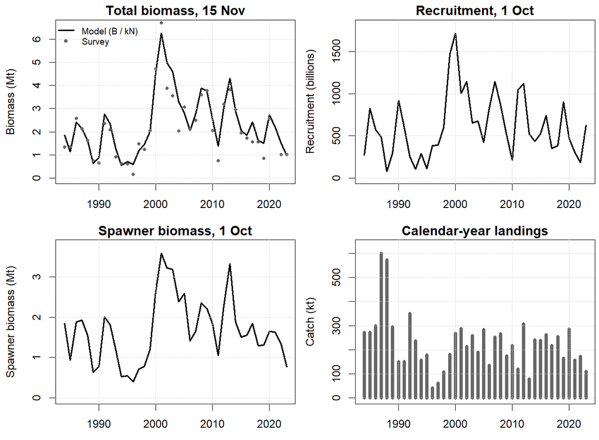

```r
library(readxl)
datafile = 'Data/SA_Anchovy_2024_estimates.xlsx'
est_yr  = as.data.frame(read_xlsx(datafile, 'ByYear'))       # biomass, SSB, recruitment, catches and survey indices by year
est_len = as.data.frame(read_xlsx(datafile, 'ByLength'))     # quarterly selectivity and age-length distributions by length class
mat_yr  = as.data.frame(read_xlsx(datafile, 'Maturity'))     # annual maturity ogive parameters
qcatch  = as.data.frame(read_xlsx(datafile, 'QuarterCatch')) # quarterly catches
est_25  = as.data.frame(read_xlsx(datafile, 'Assess2025'))   # harvest proportion from the 2025 update
SRcurve = as.data.frame(read_xlsx(datafile, 'SRcurve'))      # points along the assessment's Beverton-Holt curve
pars    = as.data.frame(read_xlsx(datafile, 'Parameters'))
getpar  = function(nam) pars$Value[pars$Name == nam]

par(mfrow = c(2,2), mai = c(0.45,0.7,0.25,0.05))
yrs = est_yr$Year
plot(yrs, est_yr$B, type = 'l', lwd = 2, ylim = c(0, max(est_yr$B)*1.05), xlab = "", ylab = "Biomass (Mt)", main = "Total biomass, 15 Nov")
points(yrs, est_yr$SurveyB, pch = 19, cex = 0.7, col = 'grey40'); grid()
legend('topleft', legend = c("Model (B / kN)", "Survey"), lwd = c(2,NA), pch = c(NA,19), col = c('black','grey40'), bty = 'n', cex = 0.8)
plot(yrs, est_yr$R, type = 'l', lwd = 2, ylim = c(0, max(est_yr$R)*1.05), xlab = "", ylab = "Recruitment (billions)", main = "Recruitment, 1 Oct"); grid()
plot(yrs, est_yr$SSB, type = 'l', lwd = 2, ylim = c(0, max(est_yr$SSB)*1.05), xlab = "", ylab = "Spawner biomass (Mt)", main = "Spawner biomass, 1 Oct"); grid()
plot(yrs, est_yr$Catch_cal, type = 'h', lwd = 4, col = 'grey40', ylim = c(0, max(est_yr$Catch_cal)*1.05), xlab = "", ylab = "Catch (kt)", main = "Calendar-year landings"); grid()
```

## 3.2 OpenMSE 2.0

OpenMSE operating models were configured to match the aggregate age-structured dynamics of the stock assessment closely matching the estimates of harvest rate, recruitment and biomass.

## 3.3 Model timing

The assessment works in quarters and the operating model is annual. The operating model year *y* is taken to run from 1 October of year *y* (the assumed date of spawning and recruitment in the assessment) to 30 September of year *y+1*. Hence:

- recruitment in operating model year *y* is the assessment recruitment at 1 October of year *y*,
- biomass at the start of operating model year *y* is compared with the assessment total biomass at 15 November of year *y* (approximately 6 weeks later), and
- the catch in operating model year *y* is the catch from October of year *y* to September of year *y+1*.

Lengths and weights at the start of the year (used to calculate biomass and spawning biomass) are those of the fourth quarter (age + 1/8 year), and the lengths and weights of the catch are an average over the quarters in which fish are caught (see below).

## 3.4 OM Initialization

```r
library(openMSE)
packageVersion('MSEtool') # should be v4x
```

```
#> [1] '4.0.0'
```

```r
# Create blank operating model and fill details
om = new('om')
om@Name = "South African Anchovy"
om@Longitude = 19
om@Latitude  = -34.5
om@Author = 'Tom Carruthers'
om@Agency = 'Blue Matter'
om@Email = 'tom@bluematterscience.com'
om@Region = "South Africa"
om@Sponsor = "The Ocean Foundation"
om@Source = "https://climatetest.bluematterscience.com"

# Basic Config
Years = est_yr$Year           # historical year labels (1984-2023)
ny = length(Years)            # number of historical years
om@nYear = ny                 # historical year
om@pYear = 50                 # 50 projected years
om@Interval = 1               # management updated every 1 year
om@DataLag = 1                # data available from last year (not in-season management)
om@nSim = 48                  # No. realisations of stock and fleet dynamics
om@CurrentYear = max(Years)   # label for most recent historical year
om@Years = Years(om)          # all year labels
om@Seasons = 1                # Annual OM
om@maxF = 3                   # maximum apical exploitation rate is 3.0 (harvest rate of 95%)
om@Seed = 1                   # random seed for stochastic sampling
om@Log[[1]] = paste("OM created:", Sys.Date())
```

## 3.5 Stock and Fleet Initialization

```r
stock = new('stock')
stock@Name = 'South African Anchovy'
stock@CommonName = 'Anchovy'
stock@Species = 'Engraulis encrasicolus'

fleet = new('fleet')
fleet@Name = "Pelagic purse-seine fleet (directed anchovy and anchovy bycatch)"
```

## 3.6 Natural mortality rate

The operating model assumes the same natural mortality as the baseline assessment, which is 1.2 per year for both juveniles (age 0) and adults (age 1+) (de Moor 2024; de Moor 2025 Table B.1). Unlike the sardine operating model, the recruitment estimates we are conditioning on are at the start of age 0 (1 October, immediately after spawning), hence age 0 is subject to the full juvenile natural mortality rate in the OM. The assessment uses a plus group of age 4.

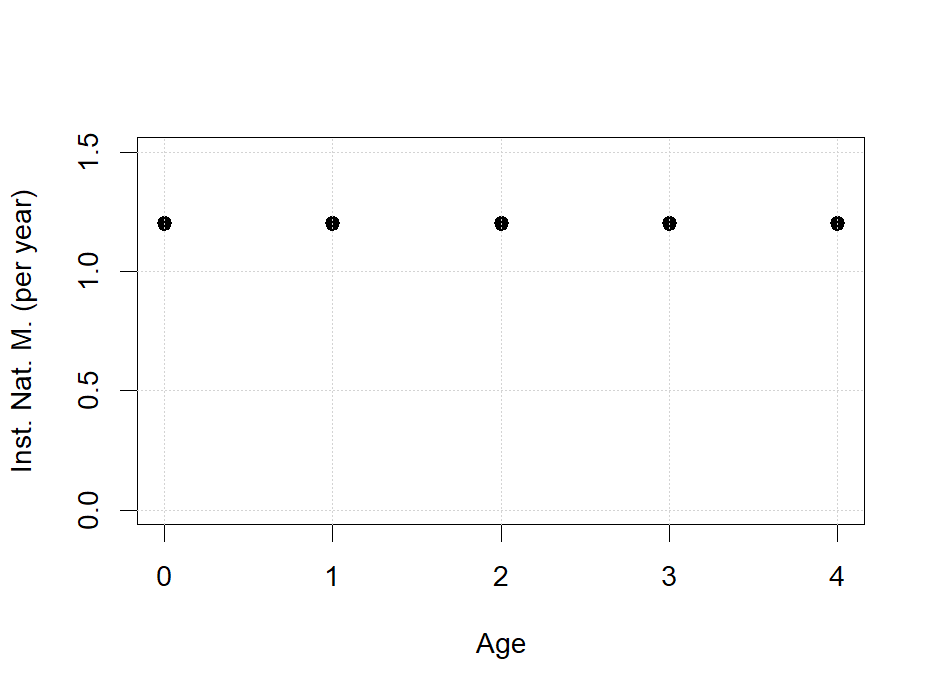

```r
M = getpar('M')
stock@Ages = Ages(4, MinAge = 0, PlusGroup = TRUE)                     # Ages 0 to 4+
ages = stock@Ages@Classes; nage = length(ages)
stock@NaturalMortality = NaturalMortality(MeanAtAge = rep(M, nage))
plot(ages, stock@NaturalMortality@MeanAtAge, pch=19, lwd=2, xlab = "Age", ylim = c(0,1.5), ylab = "Inst. Nat. M. (per year)"); grid()
```

## 3.7 Somatic Growth

The assessment assumes that length-at-age is normally distributed about a von Bertalanffy growth curve with an age at zero length of approximately 0.2 years (i.e. peak recruitment in early December). Because anchovy grow very quickly, mean length changes substantially within a year: a 0-year-old is approximately 3.6 cm in the first quarter, 7 cm in the second quarter and 9 cm in the third quarter (Figure 9 of de Moor 2024).

The operating model uses the assessment’s proportion-at-length distributions of each age at the middle of each quarter (Q1 Jan-Mar, …, Q4 Oct-Dec). Ages 3 and 4+ are assumed to have the same length distribution as age 2, which is a close approximation (Figure 9 of de Moor 2024). Fish of age 0 in the fourth quarter (i.e. just after spawning) are placed in the smallest (minus) length class.

The length-at-age of the stock is taken as the mean length in the fourth quarter (i.e. at the start of the operating model year).

```r
Lmid = est_len$Length                           # length class mid-points (cm)
quarters = c("Q4","Q1","Q2","Q3")              # order within the OM year (Oct-Sep)
tq = c(Q4 = 1/8, Q1 = 3/8, Q2 = 5/8, Q3 = 7/8)  # time of mid-quarter after 1 October (years)

ALK = function(age, q){                         # proportion-at-length of an age in a quarter
  a = min(age, 2)                               # ages 3 and 4+ use the age-2 distribution
  p = est_len[[paste0("A", a, "_", q)]]
  p / sum(p)
}

LAA_q = sapply(quarters, function(q) sapply(ages, function(a) sum(ALK(a, q) * Lmid)))  # mean length by age (rows) and quarter (cols)
rownames(LAA_q) = ages
round(LAA_q, 2)
```

```
#>      Q4    Q1    Q2    Q3
#> 0  1.75  3.63  6.97  8.94
#> 1 10.05 10.68 11.04 11.24
#> 2 11.43 11.44 11.49 11.55
#> 3 11.43 11.44 11.49 11.55
#> 4 11.43 11.44 11.49 11.55
```

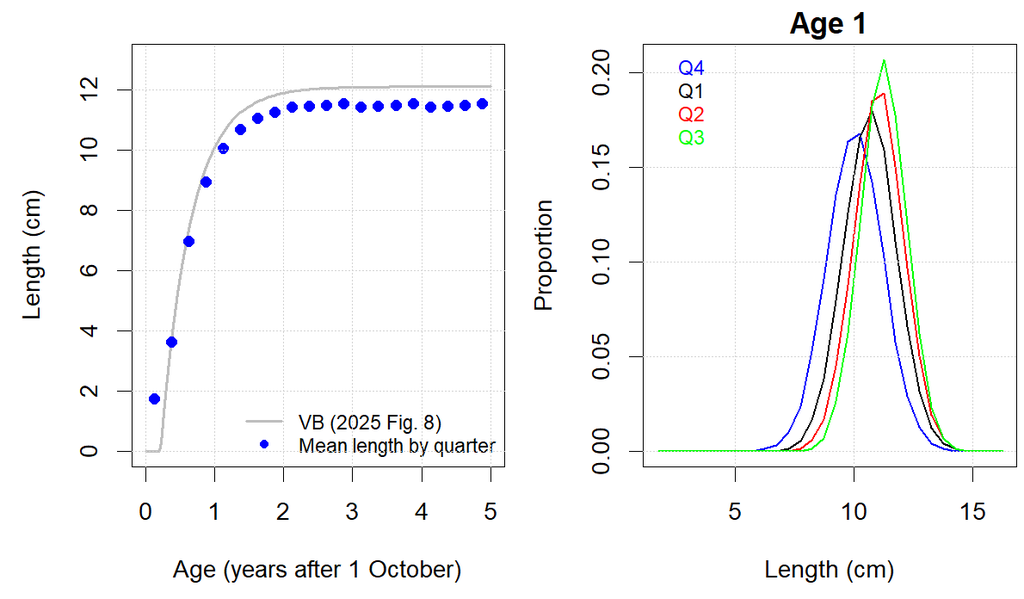

```r
stock@Length = Length(MeanAtAge = LAA_q[, "Q4"])

# von Bertalanffy fit to the 2025 assessment growth curve (digitized) for comparison
vb = function(t) getpar('Linf') * (1 - exp(-getpar('K') * (t - getpar('t0'))))
par(mfrow=c(1,2),mai=c(0.9,0.9,0.3,0.05))
tt = seq(0, 5, length.out = 200)
plot(tt, pmax(0, vb(tt)), type = 'l', lwd = 2, col = 'grey', xlab = "Age (years after 1 October)", ylab = "Length (cm)", ylim = c(0, 13))
for(q in quarters) points(ages + tq[q], LAA_q[, q], pch = 19, col = 'blue')
legend('bottomright', legend = c("VB (2025 Fig. 8)", "Mean length by quarter"), lwd = c(2, NA), pch = c(NA, 19), col = c("grey", "blue"), bty = 'n', cex = 0.8); grid()
matplot(Lmid, sapply(quarters, function(q) ALK(1, q)), type = 'l', lty = 1, lwd = 1.5, col = c("blue","black","red","green"), xlab = "Length (cm)", ylab = "Proportion", main = "Age 1"); grid()
legend('topleft', legend = quarters, text.col = c("blue","black","red","green"), bty = 'n', cex = 0.8)
```

## 3.8 Weight-at-Length

The mass-at-length relationship used in the assessment for November is (de Moor 2023; Table B.1 of de Moor 2025):

W = 0.007366 * L ^ 3.11124 (cm - g)

Weight-at-age is calculated by integrating this relationship over the length distribution of each age, rather than applying it to the mean length.

Note that if MP advice is unitless (e.g. catch in the projection relative to catch in 2023) the length-weight relationship is largely inconsequential. To obtain the same scale the length-weight relationship is exactly inversely related to unfished recruitment and numbers are not used in the model.

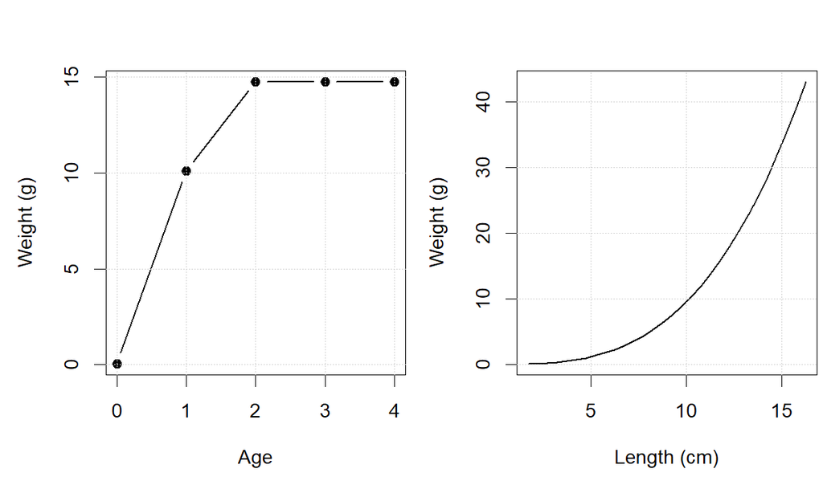

```r
wl = function(L) getpar('w_a') * L ^ getpar('w_b') / 1000      # weight (kg) at length (cm)
WAA_q = sapply(quarters, function(q) sapply(ages, function(a) sum(ALK(a, q) * wl(Lmid))))  # kg by age and quarter
rownames(WAA_q) = ages
WT = WAA_q[, "Q4"]                                                # weight at the start of the OM year
stock@Weight = Weight(MeanAtAge = WT)

par(mfrow=c(1,2),mai=c(0.9,0.9,0.6,0.05))
plot(ages, WT*1000, xlab="Age",ylab = "Weight (g)",type="b", pch=19, lwd=1.5); grid()
plot(Lmid, wl(Lmid)*1000, type="l",lwd=1.5,xlab="Length (cm)",ylab = "Weight (g)"); grid()
```

## 3.9 Maturity

The assessment assumes a logistic maturity-at-length relationship with annually varying length at 50% maturity, $L_{50,y}$, and rate of increase in maturity, $\delta_y$ (Yemane et al. 2024, as tabulated in Table B.3 of de Moor 2025). The operating model uses the average of these parameters over 1984-2024. Maturity-at-age is calculated by integrating the ogive over the length distribution of each age at the time of spawning (1 October, approximated by the fourth-quarter distribution). Age-0 fish are not mature at spawning.

Note that the relatively shallow ogive means that around 20% of ages 2+ are assumed to be immature.

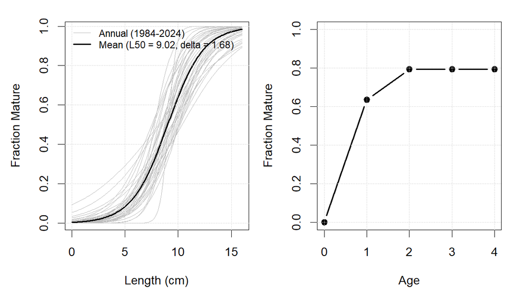

```r
L50 = mean(mat_yr$L50); delta = mean(mat_yr$delta)
ogive = function(L, L50, delta) 1 / (1 + exp(-(L - L50) / delta))
MAA = sapply(ages, function(a) sum(ALK(a, "Q4") * ogive(Lmid, L50, delta)))
MAA[1] = 0                                                         # age 0 not mature at spawning
stock@Maturity = Maturity(MeanAtAge = MAA)

par(mfrow=c(1,2),mai=c(0.9,0.9,0.3,0.05))
LL = seq(0, 16, length.out = 200)
plot(LL, ogive(LL, L50, delta), type = 'n', xlab = "Length (cm)", ylab = "Fraction Mature")
for(i in 1:nrow(mat_yr)) lines(LL, ogive(LL, mat_yr$L50[i], mat_yr$delta[i]), col = 'grey')
lines(LL, ogive(LL, L50, delta), lwd = 2); grid()
legend('topleft', legend = c("Annual (1984-2024)", paste0("Mean (L50 = ", round(L50,2), ", delta = ", round(delta,2), ")")), lwd = c(1,2), col = c("grey","black"), bty = 'n', cex = 0.8)
plot(ages, MAA, type = 'b', pch = 19, lwd = 2, ylim = c(0,1), xlab = "Age", ylab = "Fraction Mature"); grid()
```

## 3.10 Recruitment

The baseline assessment estimates a time-invariant Beverton-Holt stock-recruitment relationship between spawner biomass at 1 October and recruitment at 1 October (de Moor 2024, Figure 10). Rather than refitting this relationship to the estimates of spawner biomass and recruitment (which are not independent; see the sardine OM specification), the operating model adopts the assessment’s estimated curve.

The $\alpha$ (maximum recruitment) and $\beta$ (spawner biomass at half maximum recruitment) parameters of the curve are recovered from points along the extracted curve and then converted to unfished recruitment ($R_0$) and steepness ($h$) using the unfished spawning biomass per recruit ($\phi_0$) of the operating model:

$R_0 = \alpha - \beta / \phi_0$, $\quad h = \frac{R(0.2 S_0)}{R_0}$, where $S_0 = R_0 \phi_0$.

Recruitment deviations are calculated from the extracted spawner biomass and recruitment estimates. The assessment notes that recruitment in the final year (2023) is not well estimated, so this deviation (and those of the projection years) is generated with the same standard deviation and lag-1 autocorrelation as the 1984-2022 deviations.

```r
SSB = est_yr$SSB                      # spawner biomass at 1 October (million t)
R = est_yr$R                          # recruitment at 1 October (billions)
R[ny] = NA                            # final year recruitment is not well estimated by the assessment

BHab = function(S, a, b) a * S / (b + S)                     # Beverton-Holt in alpha-beta form
fit = nls(R ~ BHab(SSB, a, b), data = SRcurve, start = list(a = 1000, b = 0.5))
alpha = coef(fit)['a']; beta = coef(fit)['b']

surv = exp(-cumsum(c(0, rep(M, nage - 1))))                  # survivorship to the start of each age
surv[nage] = surv[nage] / (1 - exp(-M))                      # plus group
phi0 = sum(surv * MAA * WT)                                  # kg per recruit = million t per billion recruits

R0 = unname(alpha - beta / phi0)                             # unfished recruitment (billions)
S0 = R0 * phi0                                               # unfished spawner biomass (million t)
h = unname(BHab(0.2 * S0, alpha, beta) / R0)                 # steepness

RD = log(R / BHab(SSB, alpha, beta))                         # log recruitment deviations
AC = acf(RD[!is.na(RD)], 1, plot = F)$acf[2,1,1]             # lag-1 recruitment autocorrelation
SD = sd(RD, na.rm=T)                                         # lognormal recruitment process error ('sigma-R')

round(c(alpha = unname(alpha), beta = unname(beta), phi0_g = phi0 * 1000, R0 = R0, S0 = S0, h = h, SD = SD, AC = AC), 3)
```

```
#>   alpha    beta  phi0_g      R0      S0       h      SD      AC
#> 941.356   0.701   3.452 738.299   2.548   0.537   0.690   0.235
```

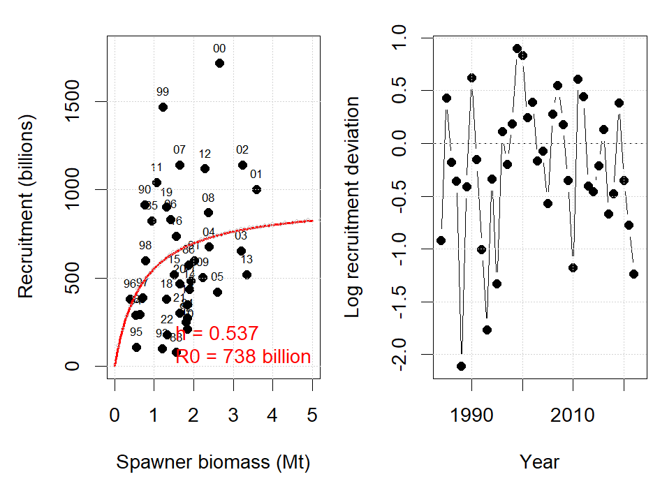

```r
par(mfrow=c(1,2),mai=c(0.9,0.9,0.3,0.05))
plot(SSB, R, pch = 19, xlim = c(0, 5), ylim = c(0, max(R, na.rm=T)*1.05), xlab = "Spawner biomass (Mt)", ylab = "Recruitment (billions)")
text(SSB, R, labels = substr(Years, 3, 4), pos = 3, cex = 0.6)
SS = seq(0, 5, length.out = 200)
lines(SS, BHab(SS, alpha, beta), col = 'red', lwd = 2)
points(SRcurve$SSB, SRcurve$R, col = 'grey', cex = 0.5)
legend('bottomright', legend = c(paste("h =", round(h,3)), paste("R0 =", round(R0), "billion")), text.col = "red", bty = "n"); grid()
plot(Years, RD, type = 'b', pch = 19, xlab = "Year", ylab = "Log recruitment deviation"); abline(h = 0, lty = 2); grid()
```

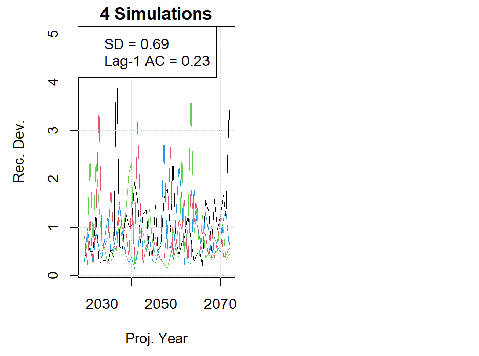

```r
DepGuess = (est_yr$B[1] / quantile(est_yr$B, 0.5))                          # depletion guess
RecDevInit = matrix(DepGuess, nrow = om@nSim, ncol = stock@Ages@MaxAge)     # initial rec devs go into year 1 of RecDevHist
RecDevHist = matrix(exp(RD), nrow = om@nSim, ncol = ny, byrow = T)          # historical rec devs
RecDevProj = matrix(NA,nrow = om@nSim, ncol = om@pYear)                     # projected rec devs
nterminal = sum(is.na(RD))                                                  # No. terminal years in need of filling
fyears = rev(rev(om@Years)[1:(nterminal + om@pYear)])                       # labels for years that need filling
res = MSEtool::GenResiduals(SD, rep(AC,om@nSim), fyears, om@nSim, TruncSD = 3,
                            LastError = RecDevHist[,ny-nterminal])          # generated residuals with AC and SD
RecDevHist[,(ny-nterminal+1):ny] = res[,1:nterminal]                        # populate terminal rec devs
RecDevProj = res[, (nterminal+1):ncol(res)]                                 # populate projected rec devs

stock@SRR = SRR(Pars=list(h=h), R0 = R0 * 1E9, AC = AC, RecDevInit = RecDevInit,  # build Stock Rec. Rel. slot
                RecDevHist = RecDevHist, RecDevProj = RecDevProj)

matplot(Years(om, Period = "P"), t(RecDevProj[1:4,]),lty=1,type="l",
        xlab="Proj. Year",ylab ="Rec. Dev.", main="4 Simulations"); grid()
legend('topleft',legend=c(paste("SD =",round(SD,2)),paste("Lag-1 AC =", round(AC,2))))
```

The assessment’s Beverton-Holt curve implies moderate resilience (steepness around 0.5). There is no trend in the recruitment residuals against spawner biomass but there is a decreasing trend in recent years (also evident in the 2025 update), which motivates the alternative stock-recruitment relationships considered by de Moor (2025b).

## 3.11 Selectivity

The assessment estimates commercial selectivity-at-length for each quarter. These are dome-shaped since larger fish are less available to the fishery. Selectivity-at-age is derived for each quarter by integrating selectivity-at-length over the length distribution of each age in that quarter. The annual selectivity-at-age is then the average of these quarterly selectivities weighted by the average fraction of the annual catch taken in each quarter (1984-2022).

The fishery is dominated by the catch of recruits (age 0) in the second and third quarters (April - September), with smaller catches of 1-year-olds in the first quarter of the year.

```r
qshare = colSums(qcatch[, c("Q4_OctDec","Q1_JanMar","Q2_AprJun","Q3_JulSep")])
qshare = qshare / sum(qshare); names(qshare) = quarters
round(qshare, 3)
```

```
#>    Q4    Q1    Q2    Q3
#> 0.046 0.161 0.453 0.340
```

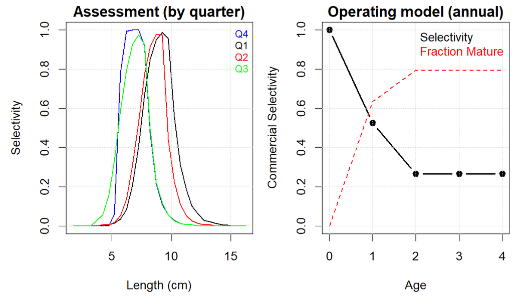

```r
SAA_q = sapply(quarters, function(q) sapply(ages, function(a) sum(ALK(a, q) * est_len[[paste0("Sel_", q)]])))
rownames(SAA_q) = ages
SAA = as.vector(SAA_q %*% qshare)
SAA = SAA / max(SAA)

fleet@Selectivity = Selectivity(MeanAtAge = SAA)

par(mfrow=c(1,2),mai=c(0.9,0.9,0.3,0.05))
qcols = c(Q4 = "blue", Q1 = "black", Q2 = "red", Q3 = "green")
matplot(Lmid, est_len[, paste0("Sel_", quarters)], type = 'l', lty = 1, lwd = 1.5, col = qcols, xlab = "Length (cm)", ylab = "Selectivity", main = "Assessment (by quarter)"); grid()
legend('topright', legend = quarters, text.col = qcols, bty = 'n', cex = 0.8)
plot(ages, SAA, type = 'b', pch = 19, lwd = 2, ylim = c(0,1), xlab = "Age", ylab = "Commercial Selectivity", main = "Operating model (annual)")
lines(ages, MAA, lwd = 1.5, lty = 2, col = 'red'); grid()
legend('topright', legend = c("Selectivity", "Fraction Mature"),text.col = c("black","red"),bty='n')
```

## 3.12 Weight of the catch

Since most of the catch is of recruits caught during their first winter, the weight of fish in the catch is substantially higher than their weight at the start of the operating model year (age-0 fish weigh close to zero at 1 October). The mean weight-at-age of the catch is calculated as the average weight in each quarter, weighted by the expected catch-at-age in numbers in that quarter (quarterly catch share x quarterly selectivity x survival to the middle of the quarter).

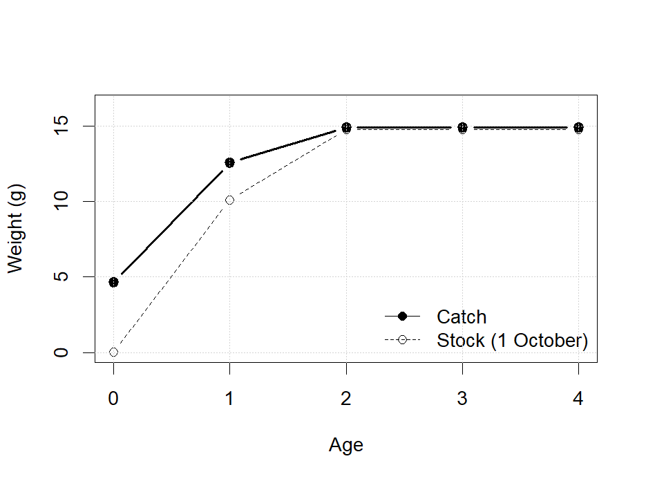

```r
cwt = sweep(SAA_q, 2, qshare, "*") * exp(-M * outer(rep(1, nage), tq[quarters]))  # relative catch numbers by age and quarter
WC = rowSums(cwt * WAA_q) / rowSums(cwt)                                          # mean weight of the catch (kg)
allyrs = om@Years                                                                 # historical and projection years
WCarray = array(rep(WC, length(allyrs)), dim = c(1, nage, length(allyrs)),
                dimnames = list(Sim = 1, Age = ages, Year = allyrs))               # Sim x Age x Year with named dimensions
fleet@WeightFleetRetained = WCarray
fleet@WeightFleetSelected = WCarray

plot(ages, WC*1000, type = 'b', pch = 19, lwd = 2, ylim = c(0, max(WC)*1100), xlab = "Age", ylab = "Weight (g)")
lines(ages, WT*1000, type = 'b', pch = 1, lty = 2)
legend('bottomright', legend = c("Catch", "Stock (1 October)"), pch = c(19, 1), lty = c(1, 2), bty = 'n'); grid()
```

## 3.13 Apical F

The 2025 update reports a time series of harvest proportion (catch in calendar year *y* divided by the model total biomass of year *y*). To match the timing of the operating model, the harvest proportion is recalculated here as the catch from October of year *y* to September of year *y+1* divided by the extracted model total biomass at 15 November of year *y*. The 2024 monthly catches are not available in the references, so the harvest proportion for the final operating model year (2023) is the 2024 harvest proportion of the 2025 update. These are converted to a guess of apical F that will be later adjusted to match historical biomass estimates.

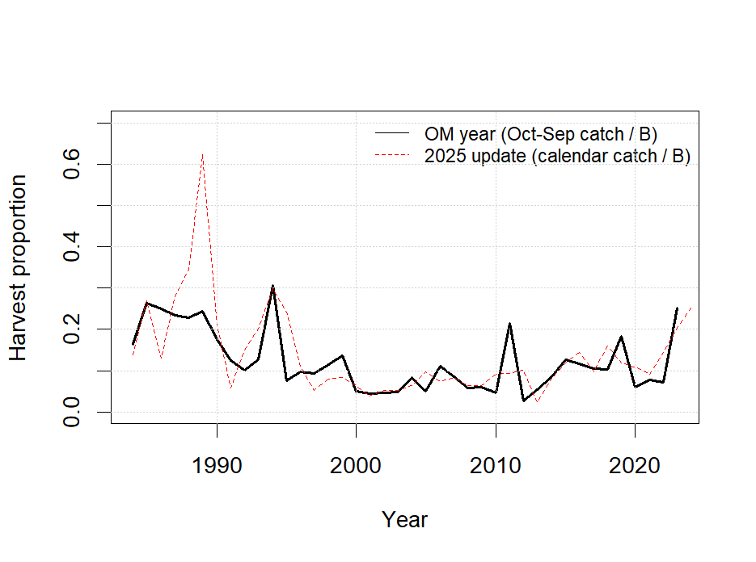

```r
U = est_yr$Catch_OctSep / 1000 / est_yr$B                     # harvest proportion: catch (Mt) / biomass (Mt)
U[ny] = est_25$U[est_25$Year == 2024]                          # terminal year from the 2025 update
Adj_vuln = 0.5                                                 # apical F applies to the selected component (approx. 50% of biomass)
F_guess = -log(1-U) / Adj_vuln                                 # initial guess of F time series
Eff = matrix(F_guess, nrow=om@nSim, ncol=ny, byrow = T,
             dimnames = list(1:om@nSim,Years(om,'h')))         # Effort matrix with correct year labels
fleet@Effort = Effort(Effort = Eff)                            # Populate historical effort slot
fleet@Catchability = Catchability(Efficiency = 1)              # Populate catchability slot, F = qE, hence F = E as specified

plot(Years, U, type = 'l', lwd = 2, ylim = c(0, 0.7), xlab = "Year", ylab = "Harvest proportion")
lines(est_25$Year, est_25$U, col = 'red', lty = 2)
legend('topright', legend = c("OM year (Oct-Sep catch / B)", "2025 update (calendar catch / B)"), lty = c(1,2), col = c("black","red"), bty = 'n', cex = 0.8); grid()
```

## 3.14 Initial OM

```r
om@Stock = stock
om@Fleet = fleet
hist = Simulate(om)
```

## 3.15 Scale optimization

Two components of the OM specification need to be adjusted to match estimated biomass, recruitment and harvest rate: unfished recruitment (scale), apical F mismatch.

To do this we initialize the OM, estimate harvest rate, biomass and recruitment and wrap this into a bivariate optimization for unfished recruitment and apical F modifiers.

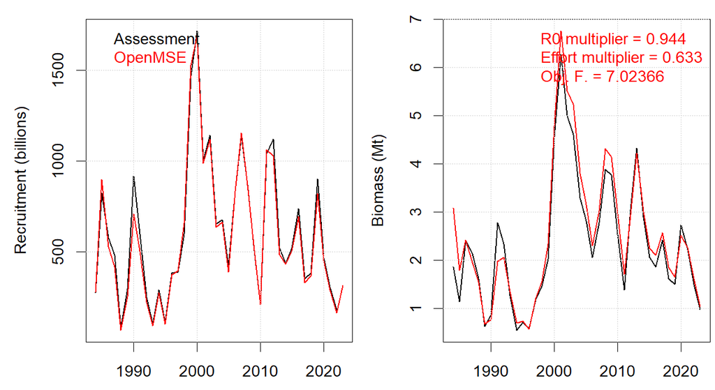

```r
ctrl = SimControl(DynamicUnfished = FALSE,
                     RefLandings = FALSE,
                     RefRemovals = FALSE,
                     ConditionObs = FALSE,
                     EstimateBeta = FALSE,
                     GenerateData = FALSE,
                     MSYRefs = FALSE,
                     RefPoints = FALSE,
                     MGT = FALSE,
                     BLow = FALSE)

B = est_yr$B                                                # Target biomass (Mt)
Rt = est_yr$R; Rt[ny] = NA                                  # Target recruitment (billions), final year excluded

Apply_pars = function(om, pars){
  R0mult = exp(pars[1])
  Emult = exp(-pars[1]) * exp(pars[2])
  om@Stock@SRR@R0 = om@Stock@SRR@R0 * R0mult
  om@Fleet@Effort@Effort =  om@Fleet@Effort@Effort * Emult
  om
}


doplot = function(om, B, R, Best, Rest, pars, obj){
  par(mfrow =c(1,2),mai=c(0.5,0.9,0.2,0.05))
  yrs = Years(om, 'h')
  matplot(yrs, cbind(R,Rest), ylab = "Recruitment (billions)", col=c("black","red"),lty=1,lwd=1.5,type = 'l');grid()
  legend('topleft',legend=c("Assessment","OpenMSE"),text.col = c("black","red"), bty="n")
  matplot(yrs,cbind(B,Best),ylab="Biomass (Mt)", col=c("black","red"),lty=1,lwd=1.5,type = 'l');grid()
  legend('topright',legend=c(paste("R0 multiplier =",round(exp(pars[1]),3)),
                            paste("Effort multiplier =",round(exp(-pars[1]) * exp(pars[2]),3)),
                            paste("Obj. F. =", round(obj,5))), text.col = "red", bty="n")
}

plotstat = function(om2, B, R, ctrl, opt){
  hist = Simulate(om2, control=ctrl)
  Best = hist@Biomass[1,1,] * 1E-9
  Rest = hist@Number[[1]][1,1,,1] * 1E-9
  doplot(om = om2, B, R, Best, Rest, pars = opt$par, obj = opt$value)

}

Int_Scale = function(pars, om, B, R, mode = 'opt', ctrl, plot=F){
  om = Apply_pars(om, pars)
  hist = Simulate(om, control = ctrl)
  Best = hist@Biomass[1,1,] * 1E-9
  Rest = hist@Number[[1]][1,1,,1] * 1E-9
  if(mode == 'opt')  obj = sum(abs(log(Best)-log(B)),na.rm=T) + sum(abs(log(Rest)-log(R)),na.rm=T)
  if(mode == 'optB')  obj = sum(abs(log(Best)-log(B)),na.rm=T)
  if(plot) doplot(om, B, R, Best, Rest, pars, obj)
  if(grepl("opt", mode)){
    return(obj)
  }else{
    pars
  }
}

opt = optim(c(0,0), Int_Scale,
      om = om, B = B, R = Rt, ctrl = ctrl, plot=F,
      method = "L-BFGS-B", control = list(factr = 1E12, maxit = 10),
      lower = c(-2, -2), upper = c(2, 2))

om2 = Apply_pars(om,opt$par)
plotstat(om2, B, Rt, ctrl, opt)
```

## 3.16 Add Generic Observation Model for MP Testing

The November hydroacoustic survey of total biomass and the May/June recruit survey are the primary indices used by the current management procedure. Here a generic observation model is specified with a total biomass survey (CV approximately equal to the median survey CV), a CPUE index and catches.

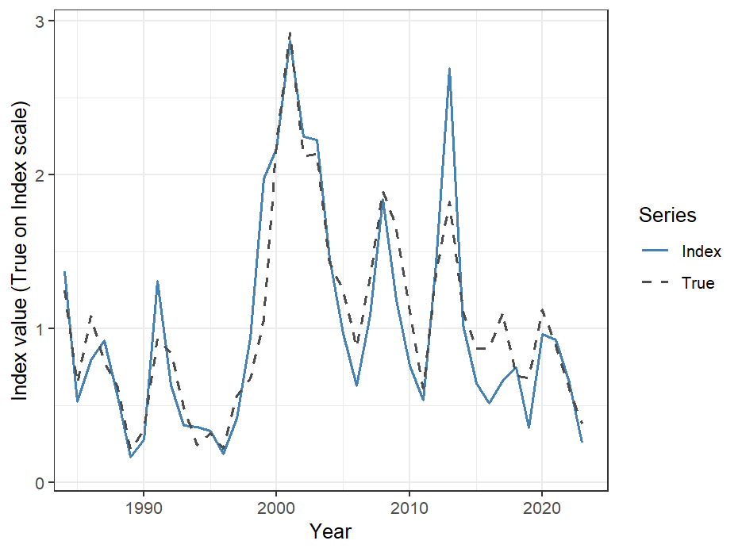

```r
ExampleObs <- Obs(CPUE = IndicesObs(CV = 0.3),                                # CPUE index
                  Survey = IndicesObs(CV = 0.2, Selectivity = 'Biomass'),     # total biomass survey (November acoustic survey)
                  Landings = CatchObs(CV = 0.025))                            # catches

Obs(om2) <- list(list(ExampleObs))                                            # assign observation error model

hist <- Simulate(om2)                                                         # historical reconstruction
PlotIndexFit(hist, 'CPUE')                                                    # plot historical CPUE
```

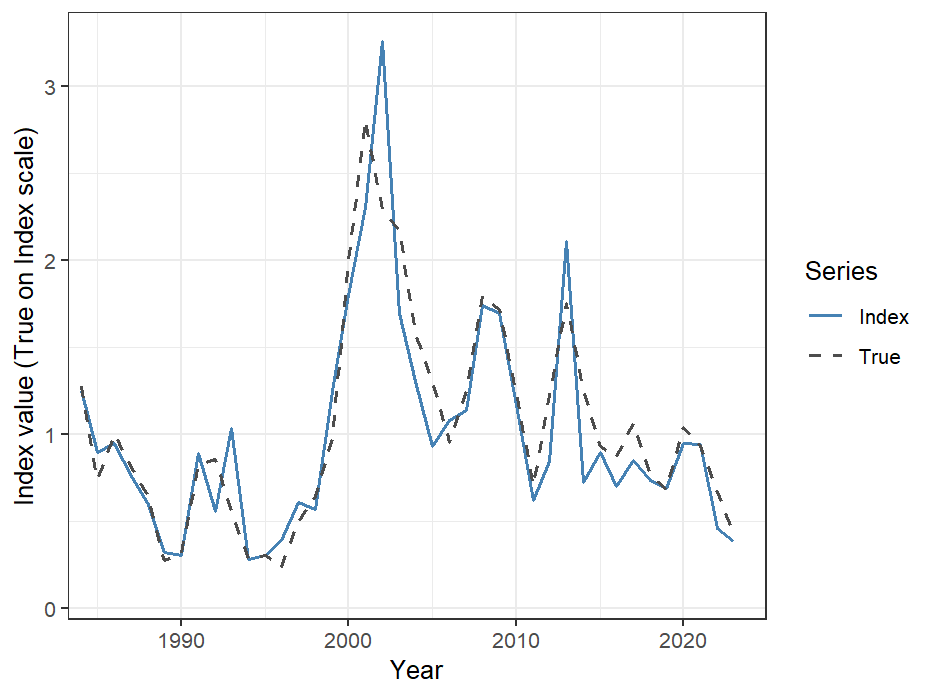

```r
PlotIndexFit(hist, 'Survey')                                                  # plot historical survey
```

```r
# Save outputs to the ClimateTest R package for lazyload
SAA = om2
if(dir.exists("C:/GitHub/ClimateTest/data")) save(SAA, file = "C:/GitHub/ClimateTest/data/SAA.rda")
```

# 4 Results

## 4.1 Assessment Comparison

The assessment model of de Moor (2024) includes quarterly dynamics, pulse fishing in each quarter, length-based selectivity and maturity, and the fitting of length-composition data. This complexity is required to correctly interpret input data to that model.

However, the aggregate stock-wide recruitment, exploitation rate and abundance is well approximated by the annual model applied here. This approximation is suitable for the purposes of this operating model, namely to comparatively rate climate robustness of potential management procedures.

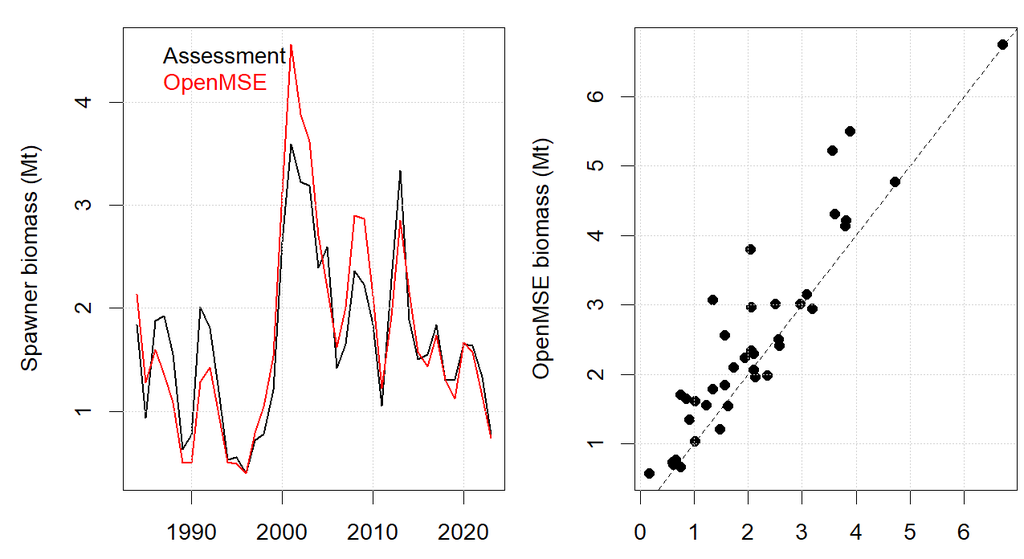

```r
Hist = Simulate(om2)
Best = Hist@Biomass[1,1,] * 1E-9
SSBest = Hist@SBiomass[1,1,] * 1E-9
par(mfrow =c(1,2),mai=c(0.5,0.9,0.2,0.05))
matplot(Years, cbind(est_yr$SSB, SSBest), type = 'l', lty = 1, lwd = 1.5, col = c("black","red"), ylab = "Spawner biomass (Mt)"); grid()
legend('topleft',legend=c("Assessment","OpenMSE"),text.col = c("black","red"), bty="n")
plot(est_yr$SurveyB, Best, pch = 19, xlab = "November survey biomass (Mt)", ylab = "OpenMSE biomass (Mt)"); abline(0, 1, lty = 2); grid()
```

Spawning biomass is not used in the conditioning and provides a check on the maturity and weight-at-age assumptions.

## 4.2 Example Projections

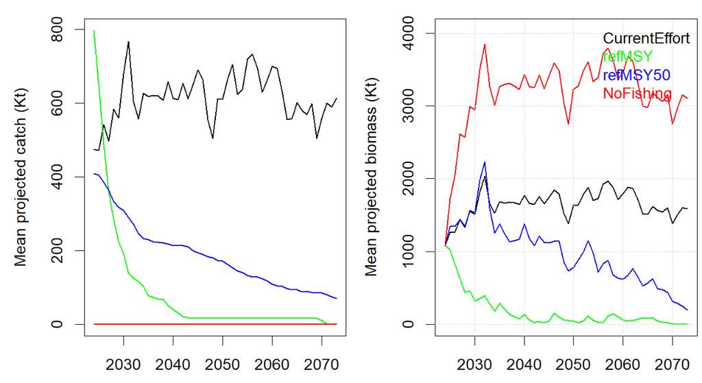

```r
MPs = c("CurrentEffort","refMSY","refMSY50","NoFishing")
Proj = Project(Hist, MPs)
muC = apply(Proj@Landings,c(3,5),mean)
muB = apply(Proj@Biomass,c(3,4),mean)
mpcols = c("black","green","blue","red")
yrs = Years(om2, 'p')
par(mfrow =c(1,2),mai=c(0.5,0.9,0.2,0.05))
matplot(yrs, muC/1E6,type="l",lty=1, lwd=1.5, ylab="Mean projected catch (Kt)", col = mpcols)
matplot(yrs, muB/1E6,type="l",lty=1, ylim = c(0, max(muB)*1.05/1E6), lwd=1.5, ylab="Mean projected biomass (Kt)", col = mpcols); grid()
legend('topright', legend=MPs, text.col=mpcols, bty="n")
```

Note that projections at the deterministic MSY fishing mortality (refMSY) deplete the stock. Given the high recruitment variability (sigma-R of approximately 0.7), the moderate steepness and the high selectivity of age-0 fish, the deterministic MSY harvest rate appears to be unsustainable in this stochastic operating model. This requires further investigation (see In Development).

# 5 Version Notes

These operating models are subject to ongoing testing and development. If you find a bug or a problem please send a report to tom@bluematterscience.com so that it can be fixed!

# 6 In Development

Outstanding tasks:

[output not shown]

# 7 Background information

Project information, links and results are available from the Climate Test [project webpage](https://blue-matter.github.io/ClimateTest/)

# 8 Software

## 8.1 OpenMSE

The [openMSE R package](https://openmse.com) was used to organize fishery data, define operating models, condition operating models to data, calculate reference points and specify and test existing and alternative management options.

Visit the [OpenMSE website](https://openmse.com) for more information on the framework including tutorial and case studies.

The Rapid Conditioning Model is also [described there](https://openmse.com/tutorial-rcm)

Other useful openMSE apps include [MERA](https://www.merafish.org/) for rapidly scoping operating models and [Reference Point Calculator](https://shiny.bluematterscience.com/app/rpc) for investigating reference points and control rules.

## 8.2 Climate Test

The Climate Test is an extension of OpenMSE that allows for comparative robustness evaluation of candidate management procedures. For more information please visit the [project splash page](https://climatetest.bluematterscience.com)

## 8.3 Management Strategy Evaluation

The Ocean Foundation host the [Harvest Strategies website](https://harveststrategies.org/) which is an excellent resource describing MSE, MSE concepts and how MSE can be used in fishery management including introductory videos and interviews with experts. ‘Harvest strategy’ and Management Procedure are synonymous by the way.

# 9 Climate Test Papers

[Carruthers, T.R.. 2024a. Developing the Climate Test: Robustness Trials for climate-ready management procedures. Col. Vol. Sci. Pap. ICCAT. 81(6): 1-26](https://www.iccat.int/Documents/CVSP/CV081_2024/n_6/CV08106104.pdf)

[Carruthers, T.R., 2024b. Developing the Climate Test: Performance Metrics of Climate Robustness. Col. Vol. Sci. Pap. ICCAT. 81(2): 1-7](https://www.iccat.int/Documents/CVSP/CV081_2024/n_2/CV08102148.pdf)

# 10 References

de Moor, C.L. 2021. The operating model for an anchovy-only OMP-18rev. DFFE: Branch Fisheries Document FISHERIES/2021/APR/SWG-PEL/20. pdf

de Moor, C.L. 2023. A revision to the South African anchovy survey length-weight relationship. DFFE: Branch Fisheries Document FISHERIES/2023/SEP/SWG-PEL/17.

de Moor, C.L. 2024. Initial results towards a new ‘benchmark’ assessment of the South African anchovy resource. DFFE: Branch Fisheries Document FISHERIES/2024/AUG/SWG-PEL/35. pdf

de Moor, C.L. 2025. Assessment of the South African anchovy resource using data up to 2024. International Stock Assessment Workshop Document IWS/2025/Sardine/BG7 (also FISHERIES/2025/OCT/SWG-PEL/55). pdf

de Moor, C.L. 2025b. Stock recruitment relationships for South African anchovy. International Stock Assessment Workshop Document IWS/2025/Sardine/P2. pdf

de Moor, C.L. 2025c. OMP-18rev calculated final anchovy TAC for 2025. DFFE: Branch Fisheries Document FISHERIES/2025/AUG/SWG-PEL/47. pdf

de Moor, C.L., Merkle, D. and Coetzee, J. 2020. The data used in the 2020 anchovy assessment. DEFF: Branch Fisheries Document FISHERIES/2020/JAN/SWG-PEL/02. pdf

de Moor, C.L., Merkle, D. and Coetzee, J. 2024. The data used in the 2024 anchovy assessment. DFFE: Branch Fisheries Document FISHERIES/2024/AUG/SWG-PEL/34. pdf

Hordyk, A., Huynh, Q., Carruthers, T. 2025. OpenMSE: An open-source R package for Management strategy evaluation, available from: https://openmse.com

Ortega-Cisneros, K., Cochrane, K.L., Fulton, E.A., Gorton, R. and Popova, E. 2018. Evaluating the effects of climate change in the southern Benguela upwelling system using the Atlantis modelling framework. Fisheries Oceanography 27: 489-503. https://doi.org/10.1111/fog.12268

Yemane, D., Geja, Y. and Coetzee, J. 2024. Modelling maturity of three pelagic fishes, anchovy (*Engraulis encrasicolus*), sardine (*Sardinops sagax*), and redeye (*Etrumeus whiteheadi*), off the coast of South Africa. DFFE: Branch Fisheries Document FISHERIES/2024/MAY/SWG-PEL/47.

# 11 Acknowledgements

ClimateTest is funded by:

The Paul M. Angell Family Foundation Oceankind The Pew Charitable Trusts

and

The Ocean Foundation in partnership with [www.HarvestStrategies.org](https://harveststrategies.org/)